# Bayes Statistics

## Визуализация распределений

На практике оптимальным подходом является визуализация апостериорных распределений совместно с точечными и интервальными оценками, отображающими несколько значений вероятности (а не только 0,025 и 0,975). Пакет `tidybayes` предоставляет для этого множество [возможностей](https://mjskay.github.io/ggdist/articles/slabinterval.html), например график типа «полуглаз» (half-eye), который по умолчанию отображает 66%-ые и 95%-ые доверительные интервалы (построенные на основе квантилей):

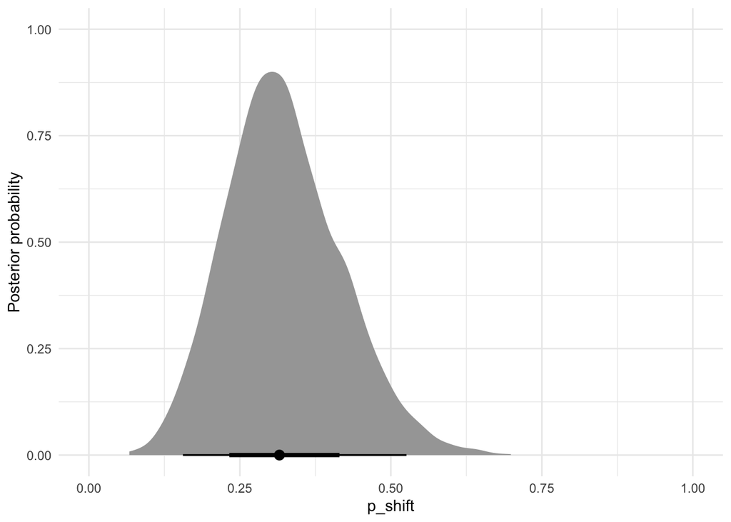

```r
diatones_m31_draws %>%
  ggplot(aes(x = b_Intercept)) +
  stat_halfeye()+
  xlab("p_shift")+
  ylab("Posterior probability") +
  xlim(0,1)
```

## Упражнение

Изучите вывод модели `diatones_m31`:

```r
diatones_m31
```

```
##  Family: binomial
##   Links: mu = identity
## Formula: stress_shifted | trials(1) ~ 0 + Intercept
##    Data: diatones[1:20, ] (Number of observations: 20)
##   Draws: 4 chains, each with iter = 2000; warmup = 1000; thin = 1;
##          total post-warmup draws = 4000
##
## Regression Coefficients:
##           Estimate Est.Error l-95% CI u-95% CI Rhat Bulk_ESS Tail_ESS
## Intercept     0.32      0.09     0.16     0.53 1.00     1734     1896
##
## Draws were sampled using sampling(NUTS). For each parameter, Bulk_ESS
## and Tail_ESS are effective sample size measures, and Rhat is the potential
## scale reduction factor on split chains (at convergence, Rhat = 1).
```

- Что означают Estimate, l-95% CI и u-95% CI? (где-то выше мы это считали :))
- Как вы думаете, что означает Est.Error?
- Проверьте свою догадку, вычислив это число, используя нашу выборку из апостериорного распределения интерцепта модели (samples_2).

## Упражнение

Создайте визуализацию апостериорного распределения для задания выше, используя samples_1 (выборки из апостериорного распределения), которая покажет как плотность распределения, так и точечные/интервальные сводки.

### Апостериорное прогностическое распределение

Выше мы рассмотрели выборку из апостериорного распределения для его обобщения: того, что модель говорит о вероятных значениях параметров. Это похоже на фреквентистские модели, где мы получаем оценки параметров, доверительные интервалы и т. д. Другое применение апостериорного распределения — понимание того, что модель говорит о правдоподобных данных: то, что МакЭлрит называет ее «подразумеваемыми прогнозами».

Неформально: поскольку байесовские модели являются генеративными, как только мы узнаем, насколько вероятны различные значения параметров (апостериорное распределение), мы можем моделировать новые данные (наблюдения), просто запуская модель вперед. Это называется dummy-, фиктивными или фейковыми данными.

Пусть $\vec{y}$ — наблюдаемые данные, $\vec{\theta}$ — значения параметров. Запуск модели дает апостериорное распределение:

$$\underbrace{P(\vec{\theta}|\vec{y})}_{posterior} \propto \underbrace{\vec{P(\vec{y}|\vec{\theta})}}_{likelyhood} \times \underbrace{\vec{P(\vec{\theta})}}_{prior}$$
Распределение вероятностей для **новых** данных $\vec{y}_{new}$ представляет собой **апостериорное предсказательное распределение** $P(\vec{y}_{new}|\vec{y})$. Правдоподобие различных значений новых данных $\vec{y}_{new}$ определяется следующим образом:

- Для каждого возможного значения параметров $\vec{\theta}$:
  - нужно вероятность вычислить вероятность $\vec{y}_{new}$ при заданном $\vec{\theta}$ (функцию правдоподобия);
  - оценить апостериорное распределение этих параметров;
  - просуммировать результаты по всем значениям параметров.

Итак, апостериорное распределение можно рассматривать как механизм для генерации новых (синтетических) наборов данных. Каждое сгенерированное наблюдение отражает два источника неопределенности:

- неопределенность в параметрах (задаваемую апостериорным распределением);
- неопределенность в самих наблюдениях при заданных значениях параметров.

Оба этих источника неопределенности распространяются (propagated) апостериорным прогностическим распределением. Давайте посмотрим на рисунок из Макэлрит (2020, 84):

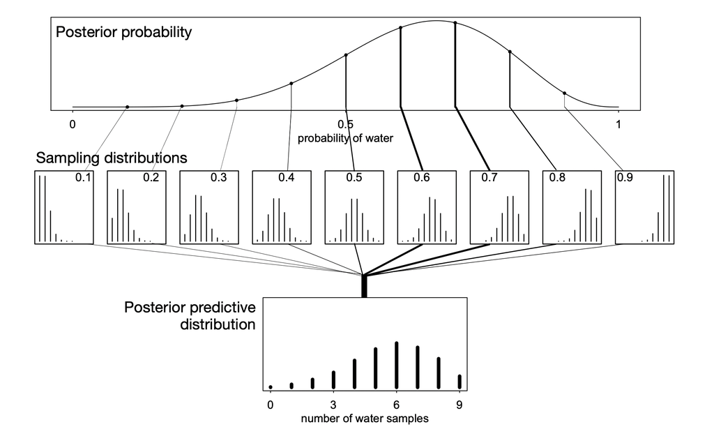

### Пример

Для модели `diatones_m31`, где $\vec{y}$ представляет собой последовательность из 20 нулей и единиц, мы можем использовать функцию `posterior_predict()` для симуляции 4000 новых выборок данных:

```r
pp_ex <- posterior_predict(diatones_m31)
head(pp_ex)
```

```
##      [,1] [,2] [,3] [,4] [,5] [,6] [,7] [,8] [,9] [,10] [,11] [,12] [,13] [,14]
## [1,]    1    1    1    0    0    1    0    0    0     0     0     0     0     1
## [2,]    0    0    0    0    0    1    1    0    0     1     0     0     0     0
## [3,]    0    0    0    0    1    1    1    0    0     0     1     0     0     1
## [4,]    0    0    0    0    0    1    0    0    0     0     0     1     0     0
## [5,]    0    1    0    0    1    0    0    1    0     0     0     1     1     0
## [6,]    0    0    1    1    0    0    0    1    0     0     1     0     0     1
##      [,15] [,16] [,17] [,18] [,19] [,20]
## [1,]     1     1     1     0     0     1
## [2,]     0     0     0     1     0     0
## [3,]     0     1     1     0     0     0
## [4,]     1     0     0     0     0     0
## [5,]     0     0     1     0     0     0
## [6,]     0     1     0     1     1     0
```

Каждая строка соответствует одной выборке, а каждый столбец — одной из 20 точек данных. Мы можем визуализировать эти смоделированные наборы данных, построив распределение *k*: количества слов со сдвинутым ударением (из 20). Это распределение выглядит следующим образом:

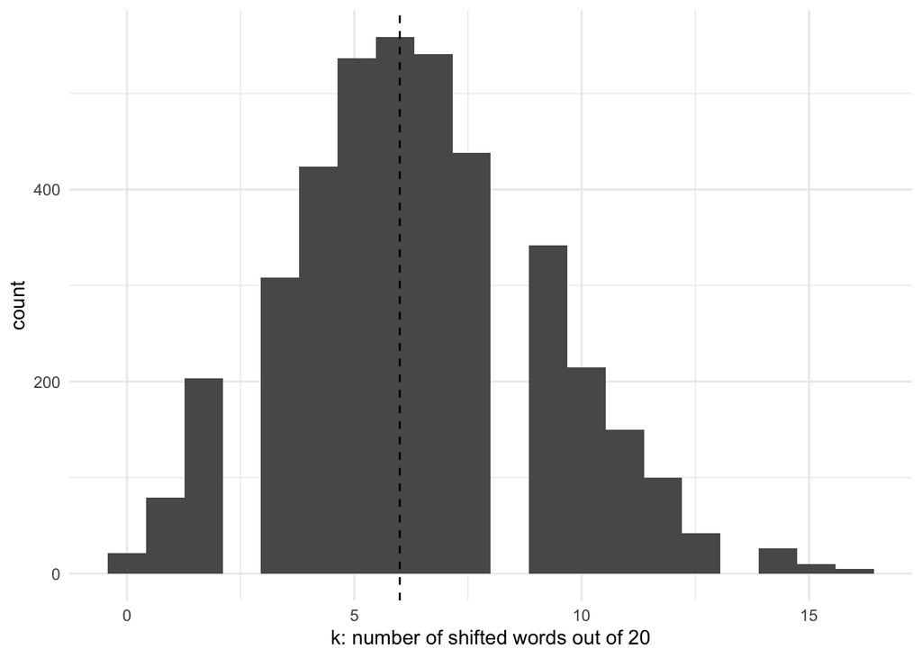

```r
data.frame(num_shifted=apply(posterior_predict(diatones_m31), 1, sum)) %>%
  ggplot(aes(x=num_shifted)) +
  geom_histogram(bins = 20) +
  geom_vline(aes(xintercept=6), lty=2) +
  ## dotted line: the *observed* number of shifted words.
  xlab("k: number of shifted words out of 20")
```

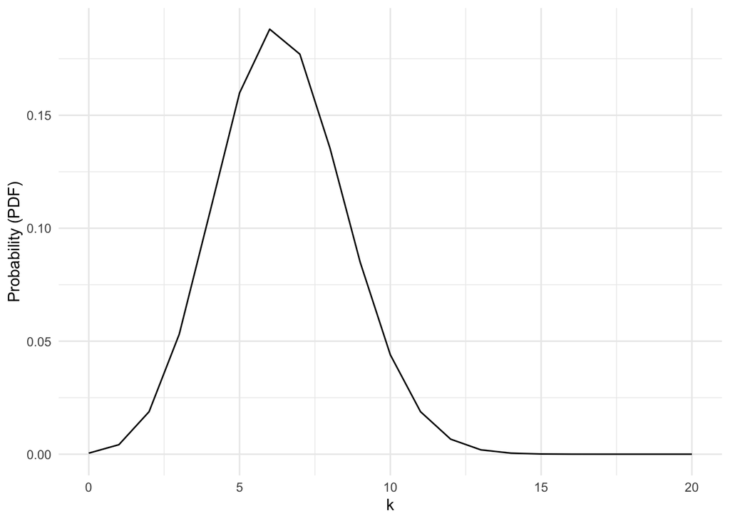

```r
k_vec <- 0:20
data.frame(k = k_vec) %>%
ggplot(aes(x=k, y=dbinom(k, 20, p=0.32))) +
  geom_line() +
  ylab("Probability (PDF)")
```

В более общем смысле апостериорное прогностическое распределение позволяет нам исследовать любую величину, которую можно вычислить на основе модели. Это преимущество не столь очевидно в случае нашей простой первой модели; мы вернемся к нему далее.

Работа с синтетическими данными, полученными из апостериорного прогностического распределения, представляет собой мощный метод, полезный для:

- проверки модели (соответствуют ли прогнозы, хотя бы приблизительно, наблюдаемым данным?);
- оценки дизайна модели (будет ли данная модель выполнять то, что мы от нее ожидаем, с учетом всех ее составных элементов?);
- валидации программного обеспечения (если мы сгенерируем данные из известного распределения, а затем построим на их основе модель, получим ли мы в итоге корректные значения параметров?);
- прогнозирования и интерпретации модели (что именно предсказывает данная модель для случаев, имеющих отношение к нашим исследовательским вопросам? А для новых случаев?).

## Полезное

- Материал и код основан на учебнике https://people.linguistics.mcgill.ca/~morgan/adv-quant-methods/bayesian-basics-1.html
- Kurz, S. 2023. Statistical Rethinking (Second Edition) with Brms, Ggplot2, and the Tidyverse. https://bookdown.org/content/4857/ (библиотеки tidyverse и brms), в свою очередь, это новый код для учебника:
- McElreath, Richard. 2020. Statistical Rethinking: A Bayesian Course with Examples in R and Stan. Second. Chapman; Hall/CRC (библиотека Stan)
- Не всякий статистический метод, использующий байесовское правило, автоматически становится “байесовским”, (McElreath pp. 38-39 box).
- Симпатичная визуализация марковских цепей https://setosa.io/blog/2014/07/26/markov-chains/
- Введение в Марковские цепи Монте-Карло https://agricolamz.github.io/2024_HSE_b_da4l/09-Introduction-to-MCMC.html
- Умеренно популярное объяснение алгоритма Метрополиса-Гастингса https://habr.com/ru/companies/piter/articles/491268/
- Список сопряженных априорных распределений (conjugate prior) из Википедии: https://ru.wikipedia.org/wiki/%D0%A1%D0%BE%D0%BF%D1%80%D1%8F%D0%B6%D1%91%D0%BD%D0%BD%D0%BE%D0%B5_%D0%B0%D0%BF%D1%80%D0%B8%D0%BE%D1%80%D0%BD%D0%BE%D0%B5_%D1%80%D0%B0%D1%81%D0%BF%D1%80%D0%B5%D0%B4%D0%B5%D0%BB%D0%B5%D0%BD%D0%B8%D0%B5